# Spread to Tidy Data

Alison Hill & Daniel Anderson

30 October, 2018

This is a lesson on tidying/untidying data, remixed from [Jenny Bryan’s similar lesson using “Lord of the Rings” data](https://github.com/jennybc/lotr-tidy). Most text + code is Jenny’s, basically we plopped a new dataset in there 😉

Enough about tidy data. How do I make it messy?

Regardless of which `gather`ing adventure you embarked upon, we’ll all use the Bachelor/Bachelorette data from [538](https://github.com/fivethirtyeight/data/tree/master/bachelorette) to practice spreading.

# Import & Tidy

Use the following code to read in and tidy the data (Note: you’ll get a bunch of parsing errors and that is OK to ignore):

```r
# load package
library(tidyverse)

# import and tidy
b_tidy <- read_csv("https://raw.githubusercontent.com/fivethirtyeight/data/master/bachelorette/bachelorette.csv",
                         col_types = cols(SEASON = col_integer())) %>%
  filter(!SEASON == "SEASON") %>%
  select(SHOW, SEASON, CONTESTANT, starts_with("ELIMINATION")) %>%
  gather(key = "week", value = "eliminated", starts_with("ELIMINATION"), na.rm = TRUE) %>%
  mutate(week = str_replace(week, "-", "_"),
         week = parse_number(week))
```

# Explore

What are the possible values in the new `eliminated` column? (hint: `distinct` possible values)

```
#> # A tibble: 8 x 1
#>   eliminated
#>   <chr>
#> 1 R1
#> 2 E
#> 3 EQ
#> 4 EF
#> 5 EU
#> 6 R
#> 7 ED
#> 8 W
```

What do those mean? Here is a key:

- “E” connotes a standard elimination, typically at a rose ceremony.
- “EQ” means the contestant quits.
- “EF” means the contestant was fired by production.
- “ED” connotes a date elimination.
- “EU” connotes an unscheduled elimination, one that takes place at a time outside of a date or rose ceremony.
- “R” means the contestant received a rose.
- “R1” means the contestant got a first impression rose.
- “W” means the contestant won.

# Count

Using that tidy data, `count` the values in your new `eliminated` column by contestant name and show.

```
#> # A tibble: 1,128 x 4
#>    CONTESTANT     SHOW         eliminated     n
#>    <chr>          <chr>        <chr>      <int>
#>  1 01_ALEXA_X     Bachelor     E              1
#>  2 01_AMANDA_M    Bachelor     W              1
#>  3 01_AMBER_X     Bachelor     E              1
#>  4 01_AMY_X       Bachelor     E              1
#>  5 01_ANGELA_X    Bachelor     E              1
#>  6 01_ANGELIQUE_X Bachelor     E              1
#>  7 01_BILLY_X     Bachelorette E              1
#>  8 01_BOB_G       Bachelorette E              1
#>  9 01_BRIAN_C     Bachelorette E              1
#> 10 01_BRIAN_H     Bachelorette EQ             1
#> # ... with 1,118 more rows
```

We need to reshape this data (again).

# Spread

Let’s `spread` that counted data, so that we get a column for each possible value in the `eliminated` column, and those columns hold the values in the `n` column. Set `fill` to 0.

|  | CONTESTANT | SHOW | E | ED | EF | EQ | EU | R | R1 | W |
| --- | --- | --- | --- | --- | --- | --- | --- | --- | --- | --- |
| 1 | 01_ALEXA_X | Bachelor | 1 | 0 | 0 | 0 | 0 | 0 | 0 | 0 |
| 2 | 01_AMANDA_M | Bachelor | 0 | 0 | 0 | 0 | 0 | 0 | 0 | 1 |
| 3 | 01_AMBER_X | Bachelor | 1 | 0 | 0 | 0 | 0 | 0 | 0 | 0 |
| 4 | 01_AMY_X | Bachelor | 1 | 0 | 0 | 0 | 0 | 0 | 0 | 0 |
| 5 | 01_ANGELA_X | Bachelor | 1 | 0 | 0 | 0 | 0 | 0 | 0 | 0 |
| 6 | 01_ANGELIQUE_X | Bachelor | 1 | 0 | 0 | 0 | 0 | 0 | 0 | 0 |
| 7 | 01_BILLY_X | Bachelorette | 1 | 0 | 0 | 0 | 0 | 0 | 0 | 0 |
| 8 | 01_BOB_G | Bachelorette | 1 | 0 | 0 | 0 | 0 | 0 | 0 | 0 |
| 9 | 01_BRIAN_C | Bachelorette | 1 | 0 | 0 | 0 | 0 | 0 | 0 | 0 |
| 10 | 01_BRIAN_H | Bachelorette | 0 | 0 | 0 | 1 | 0 | 0 | 0 | 0 |

[output cut: 873 more lines]

# Plot

Make a facetted bar plot with this data to show how many winning/losing contestants (hint: `geom_col()` might be a good choice here) in each show got first impression roses.

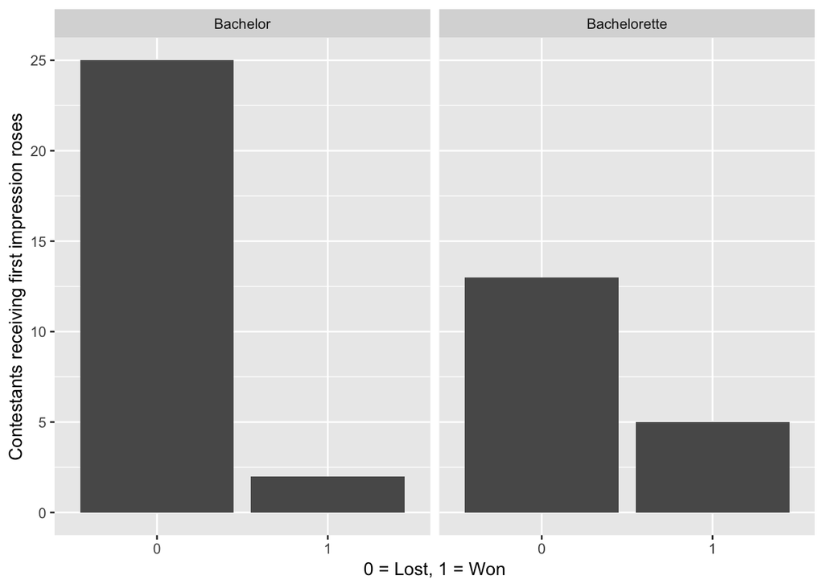

# Bonus material

Calculate percentages of contestants in each show to answer what percentage of contestants that got a first impression rose were not winners?

```r
# use tidy data to calculate percentages
(bummers <- first_impressions %>%
  count(SHOW, R1, W) %>%
  add_count(SHOW, R1, wt = n) %>%
  mutate(perc = n/nn * 100))
```

```
#> # A tibble: 8 x 6
#>   SHOW            R1     W     n    nn  perc
#>   <chr>        <dbl> <dbl> <int> <int> <dbl>
#> 1 Bachelor         0     0   501   519 96.5
#> 2 Bachelor         0     1    18   519  3.47
#> 3 Bachelor         1     0    25    27 92.6
#> 4 Bachelor         1     1     2    27  7.41
#> 5 Bachelorette     0     0   311   319 97.5
#> 6 Bachelorette     0     1     8   319  2.51
#> 7 Bachelorette     1     0    13    18 72.2
#> 8 Bachelorette     1     1     5    18 27.8
```

Answers: Only 7.41 % of Bachelor contestants who got a first impression rose won. Bachelorette contestants were a little better off: 27.78 % who got a first impression rose won.

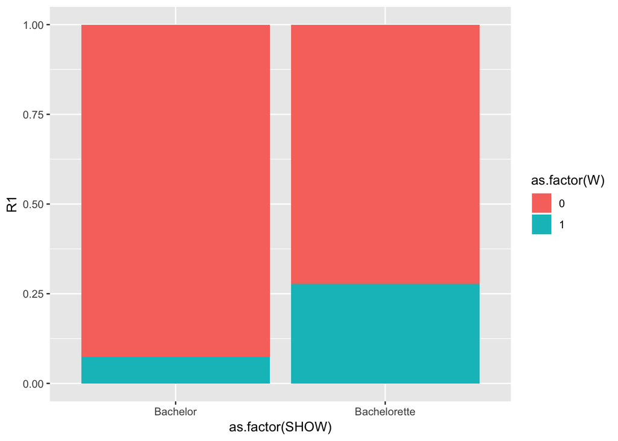

```r
# plot percentages
ggplot(first_impressions, aes(x = as.factor(SHOW), y = R1, fill = as.factor(W))) +
  geom_col(position = "fill")
```

# Code Appendix

```r
knitr::opts_chunk$set(error = TRUE, collapse = TRUE, comment = "#>", warning = FALSE, message = FALSE)
library(DT)
# load package
library(tidyverse)

# import and tidy
b_tidy <- read_csv("https://raw.githubusercontent.com/fivethirtyeight/data/master/bachelorette/bachelorette.csv",
                         col_types = cols(SEASON = col_integer())) %>%
  filter(!SEASON == "SEASON") %>%
  select(SHOW, SEASON, CONTESTANT, starts_with("ELIMINATION")) %>%
  gather(key = "week", value = "eliminated", starts_with("ELIMINATION"), na.rm = TRUE) %>%
  mutate(week = str_replace(week, "-", "_"),
         week = parse_number(week))

# what are the distinct values in this column?
b_tidy %>%
  distinct(eliminated)

# count eliminated by contestant name and show
b_counts <- b_tidy %>%
  count(CONTESTANT, SHOW, eliminated)
b_counts

# spread eliminated counts
first_impressions <- b_counts %>%
  spread(eliminated, n, fill = 0)

# make interactive table to explore
datatable(first_impressions)
# make facetted bar chart
ggplot(first_impressions, aes(x = as.factor(W), y = R1)) +
  geom_col() +
  facet_wrap(~SHOW) +
  labs(x = "0 = Lost, 1 = Won", y = "Contestants receiving first impression roses")

# use tidy data to calculate percentages
(bummers <- first_impressions %>%
  count(SHOW, R1, W) %>%
  add_count(SHOW, R1, wt = n) %>%
  mutate(perc = n/nn * 100))

# plot percentages
ggplot(first_impressions, aes(x = as.factor(SHOW), y = R1, fill = as.factor(W))) +
  geom_col(position = "fill")
```